# Report 5

Advay Vyas

February 16, 2026

# Introduction

This week, I will analyze the two FluSight models I have shortlisted and take some notes (which will be stored here). I will try to find some real trends (maybe with linear regression or a deeper analysis of that correlation plot) to look at DTW metrics in more detail. I also want to look at how trends happen over HSAs (? possibly because then I could take a look at some outliers) and look at how trends in states actually do different things. Also also, I think I can look at every row (HSA ID) now because the code is more optimized so that’s nice. Looking forward to it!

# Data processing

```r
hsa_state = read.csv("../hsa_state_inc.csv")
```

## Metric functions

```r
source("../metric_functions.R")
source("../graphstat_functions.R")
source("../write_dtw.R")
```

```r
# set.seed(77) id_list = hsa_state$hsa_nci_id id =
# sample(id_list, 1) graph_hsa(hsa_id = id)
# knitr::kable(dtw_stats(hsa_id = id), digits = 3)
```

```r
dtw_results = read_csv("../all_dtw_results.csv")
hsa_dtw = dtw_results |> left_join(hsa_state, by = join_by(ID == hsa_nci_id))

metrics = setdiff(names(dtw_results), "ID")
summary = reshape(do.call(rbind, lapply(metrics, \(m) data.frame(Metric = m, Var2 = names(summary(dtw_results[[m]])), Freq = as.numeric(summary(dtw_results[[m]])), row.names = NULL))), idvar = "Metric", timevar = "Var2", direction = "wide")
colnames(summary) = c("Metric", "Minimum", "1st Quartile", "Median", "Mean", "3rd Quartile", "Maximum")
rownames(summary) = NULL

knitr::kable(summary |> mutate(across(where(is.numeric), ~ round(., 3))), caption = "Summary Statistics for Dynamic Time Warping Metrics (+ Frechet) on HSA IDs sampled with stratification (state)")
```

Summary Statistics for Dynamic Time Warping Metrics (+ Frechet) on HSA IDs sampled with stratification (state)

| Metric | Minimum | 1st Quartile | Median | Mean | 3rd Quartile | Maximum |
| --- | --- | --- | --- | --- | --- | --- |
| mean_abs_lag | 0.109 | 1.836 | 2.561 | 3.688 | 3.561 | 64.171 |
| signed_lag | -33.662 | -0.834 | 0.079 | 0.351 | 0.892 | 64.171 |
| lag_sd | 0.332 | 2.388 | 3.362 | 4.386 | 4.841 | 36.435 |
| dtw_mae | 0.023 | 0.220 | 0.309 | 0.388 | 0.474 | 2.233 |
| dtw_rmse | 0.044 | 0.488 | 0.701 | 0.910 | 1.057 | 12.130 |
| rmse | 0.050 | 0.827 | 1.193 | 1.401 | 1.712 | 13.768 |
| amp_ratio | 0.000 | 0.226 | 0.719 | 0.658 | 0.968 | 2.931 |
| dtw_amp_ratio | 0.000 | 0.769 | 0.929 | 0.767 | 0.994 | 1.131 |
| lag_amp_corr | -0.449 | -0.245 | -0.177 | -0.146 | -0.070 | 0.386 |
| frechet | 0.250 | 2.790 | 4.295 | 5.683 | 6.580 | 90.080 |

# More plots (with interpretations)

## Trends per state

```r
dtw_results_long = dtw_results |>
    pivot_longer(cols = -ID, names_to = "metric", values_to = "value")

id_state_lookup = hsa_dtw |>
    select(ID, state) |>
    distinct()

id_state_lookup$ID = as.numeric(id_state_lookup$ID)

dtw_results_long = dtw_results_long |>
    left_join(id_state_lookup, by = "ID")

# state_counts = id_state_lookup %>% group_by(state) %>%
# summarise(n = n())
```

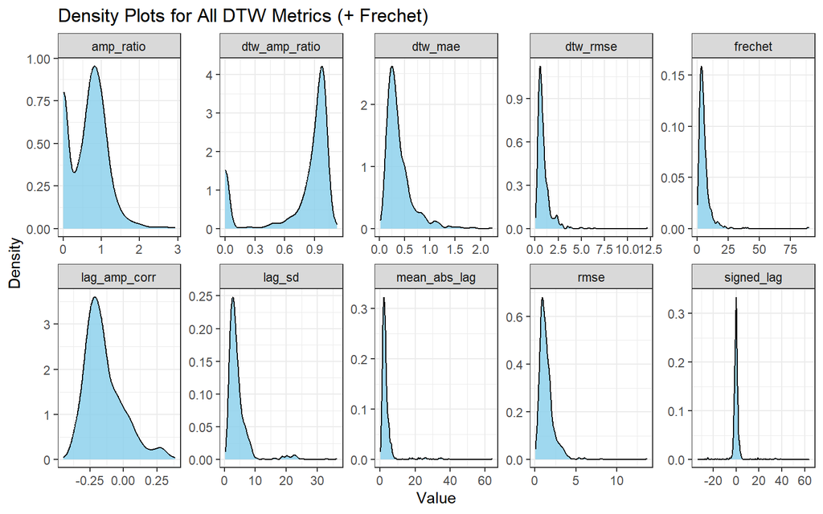

```r
ggplot(dtw_results_long, aes(x = value)) + geom_density(fill = "skyblue",
    alpha = 0.8) + facet_wrap(~metric, scales = "free", nrow = 2) +
    theme_bw() + labs(title = "Density Plots for All DTW Metrics (+ Frechet)",
    x = "Value", y = "Density")
```

Remember from the last report that lag_amp_corr is the correlation between absolute time lag and amplitude warped difference where positive values suggest larger timing shifts coincide with larger amplitude differences while negative values suggest that larger timing shifts coincide with smaller amplitude differences. We can see that as a general rule, larger timing shifts coincide with smaller amplitude differences since most medians are negative or around 0, . A few very curious correlation values are North Carolina, which has its entire distribution of 30 HSAs under the 0 mark. Looking at some of the other graphs, North Carolina looks like a special state in terms of these metrics. By the way, this means that the larger the timing shift, the smaller the amplitude difference in North Carolina - interesting stuff.

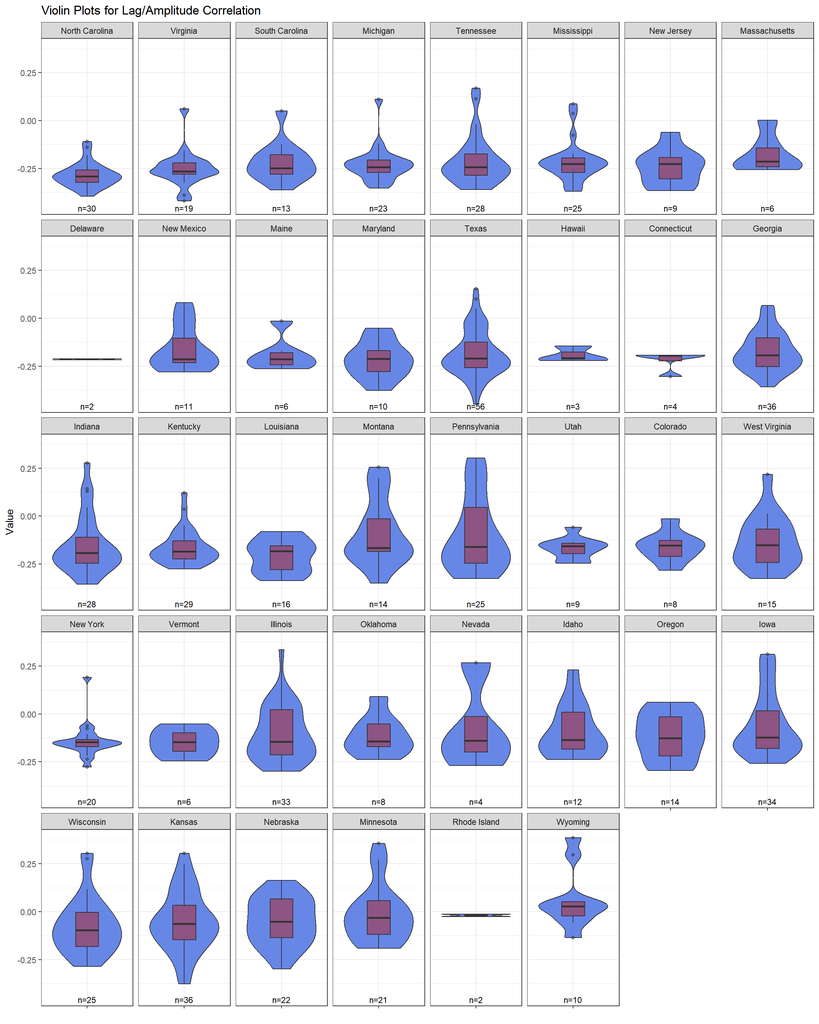

```r
dtw_lagamp_corr = dtw_results_long |>
    filter(metric == "lag_amp_corr")

state_order = dtw_lagamp_corr |>
    group_by(state) |>
    summarise(med = median(value, na.rm = TRUE), .groups = "drop") |>
    arrange((med)) |>
    pull(state)

dtw_lagamp_corr$state = factor(dtw_lagamp_corr$state, levels = state_order)

state_counts = dtw_lagamp_corr |>
    count(state)

ggplot(dtw_lagamp_corr, aes(x = "", y = value)) + geom_violin(fill = "royalblue",
    alpha = 0.8) + geom_boxplot(fill = "firebrick", alpha = 0.5,
    width = 0.3) + facet_wrap(~state, nrow = 5) + theme_bw() +
    labs(title = "Violin Plots for Lag/Amplitude Correlation",
        x = NULL, y = "Value") + geom_text(data = state_counts,
    aes(x = 1, y = -Inf, label = paste0("n=", n)), vjust = -0.5,
    inherit.aes = FALSE, size = 3)
```

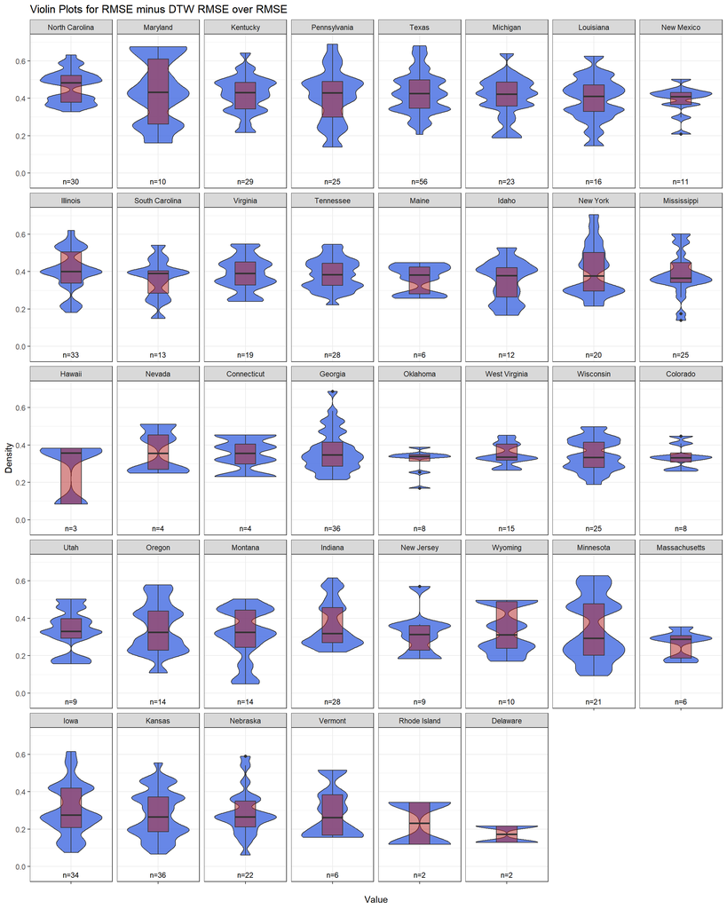

```r
dtw_results_diff = hsa_dtw |>
    mutate(dtw_diff = (rmse - dtw_rmse)/rmse)

state_order = dtw_results_diff |>
    group_by(state) |>
    summarise(med = median(dtw_diff, na.rm = TRUE), .groups = "drop") |>
    arrange(desc(med)) |>
    pull(state)

dtw_results_diff$state = factor(dtw_results_diff$state, levels = state_order)

ggplot(dtw_results_diff, aes(x = "", y = dtw_diff)) + geom_violin(fill = "royalblue",
    alpha = 0.8) + geom_boxplot(fill = "firebrick", alpha = 0.5,
    width = 0.3) + theme_bw() + facet_wrap(~state, nrow = 5) +
    labs(title = "Violin Plots for RMSE minus DTW RMSE over RMSE",
        x = "Value", y = "Density") + geom_text(data = state_counts,
    aes(x = 1, y = min(dtw_results_diff$rmse - dtw_results_diff$dtw_rmse) -
        0.05, label = paste0("n=", n)), inherit.aes = FALSE,
    size = 3)
```

I feel like the violin plots are very hard to interpret for this variable difference.

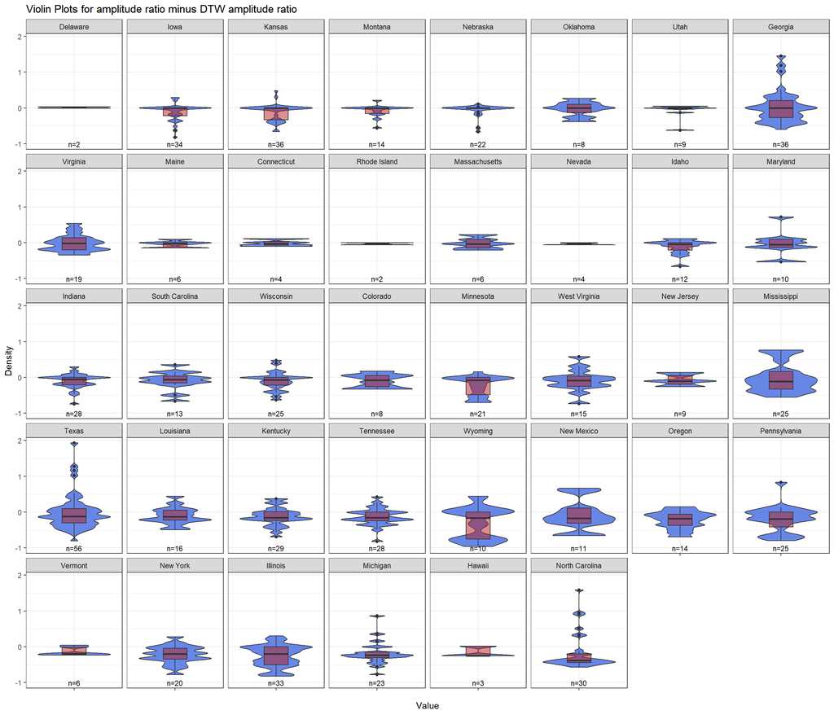

```r
dtw_results_diff_amp = hsa_dtw |>
    mutate(dtw_diff_amp = (amp_ratio - dtw_amp_ratio))

state_order = dtw_results_diff_amp |>
    group_by(state) |>
    summarise(med = median(dtw_diff_amp, na.rm = TRUE), .groups = "drop") |>
    arrange(desc(med)) |>
    pull(state)

dtw_results_diff_amp$state = factor(dtw_results_diff_amp$state,
    levels = state_order)

ggplot(dtw_results_diff_amp, aes(x = "", y = dtw_diff_amp)) +
    geom_violin(fill = "royalblue", alpha = 0.8) + geom_boxplot(fill = "firebrick",
    alpha = 0.5, width = 0.3) + theme_bw() + facet_wrap(~state,
    nrow = 5) + labs(title = "Violin Plots for amplitude ratio minus DTW amplitude ratio",
    x = "Value", y = "Density") + geom_text(data = state_counts,
    aes(x = 1, y = min(dtw_results_diff_amp$amp_ratio - dtw_results_diff_amp$dtw_amp_ratio) -
        0.05, label = paste0("n=", n)), inherit.aes = FALSE,
    size = 3)
```

Most states have their values on one side of the line, usually the left line, because DTW often improves how close the amplitude ratio is to 1. For example, states like Illinois and Oregon see a significant collection on one side of the line. However, a couple interesting states (with reasonable $n$ values) that have a more “even” distribution are Virginia, Texas, Georgia, Tennessee, Louisiana and West Virginia. One possible correlation with those states is that they are all southern states and states like Minnesota, Iowa, Idaho, Indiana, New York are all northern. However, Kentucky emerges as an exception so maybe not completely north vs. south. For a state to have a more equal distribution on each side of the line, that means that amplitudes were both above and below the state line. More specifically, if points are to the left and up from the red line, that means that the original amplitude ratio was smaller than the DTW (it fit the original from HSA being smaller to being closer). On the other hand, if points are to the right and down from the red line, that means that the original amplitude ratio was larger than the DTW.

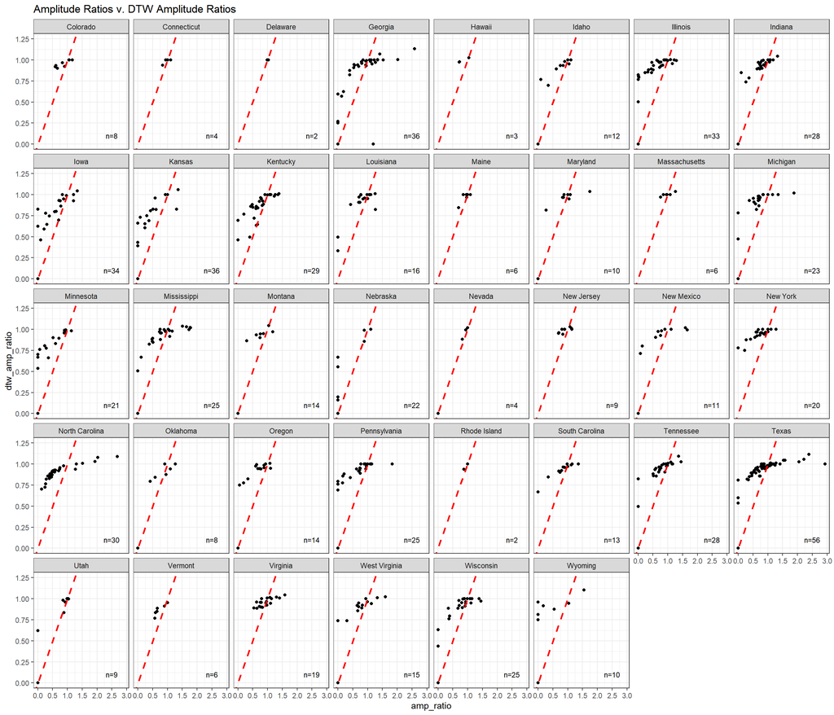

```r
ggplot(hsa_dtw, aes(x = amp_ratio, y = dtw_amp_ratio)) + geom_point() +
    geom_abline(intercept = 0, slope = 1, linetype = "dashed",
        color = "red", linewidth = 1) + labs(x = "amp_ratio",
    y = "dtw_amp_ratio", title = "Amplitude Ratios v. DTW Amplitude Ratios") +
    theme_bw() + facet_wrap(~state, nrow = 5) + geom_text(data = state_counts,
    aes(x = 2.5, y = 0.1, label = paste0("n=", n)), inherit.aes = FALSE,
    size = 3) + scale_y_continuous(breaks = c(0, 0.25, 0.5, 0.75,
    1, 1.25), limits = c(0, 1.25)) + scale_x_continuous(breaks = c(0,
    0.5, 1, 1.5, 2, 2.5, 3))
```

# Conclusion

Not much state trends abound, but maybe north vs. south is a possible plot line we can hang onto for the future. Visualization is going well for the most part, I think everything is well contextualized. The graph descriptions make sense to me. Next week (this week), want to be able to implement FluSight models and maybe test these DTW metrics on them to see how good they are at describing real models. Also, might want to take a second look at that correlation plot from last week.